# Predicting Heart Disease with Machine Learning

## Introduction: The Problem

Cardiovascular disease remains the leading cause of death globally. Early detection can save lives, but identifying individuals at risk can require costly or invasive tests.

The overarching question I am to answer is, "Can we use patient health indicators to predict the likelihood of heart disease?"

For this project, I will:

1. Build a classification model that predicts whether a patient has heart disease (1) or not (0).
2. Explore which factors (e.g., age, cholesterol, chest pain) are most predictive.
3. Compare multiple classification algorithms to determine which performs best.

## Data Introduction

I am using the **Heart Disease Dataset** from Kaggle: https://www.kaggle.com/datasets/johnsmith88/heart-disease-dataset

**Features:**

- `age`: Patient’s age (years)
- `sex`: 1 = male, 0 = female
- `cp`: Chest pain type (0–3, indicating increasing severity)
- `trestbps`: Resting blood pressure (mm Hg)
- `chol`: Serum cholesterol (mg/dl)
- `fbs`: Fasting blood sugar > 120 mg/dl (1 = true, 0 = false)
- `restecg`: Resting electrocardiographic results (0–2)
- `thalach`: Maximum heart rate achieved
- `exang`: Exercise induced angina (1 = yes, 0 = no)
- `oldpeak`: ST depression induced by exercise
- `slope`: Slope of the peak exercise ST segment (0–2)
- `ca`: Number of major vessels (0–3)
- `thal`: Thalassemia (0–3)
- `target`: 1 = heart disease, 0 = no heart disease

```python
# pandas/numpy for data handling, matplotlib/seaborn for visualizations
# sklearn for preprocessing and modeling as well as the metrics
import pandas as pd
import numpy as np
import matplotlib.pyplot as plt
import seaborn as sns

from sklearn.model_selection import train_test_split, cross_val_score
from sklearn.preprocessing import StandardScaler
from sklearn.metrics import (
    accuracy_score, precision_score, recall_score,
    f1_score, roc_auc_score, classification_report, RocCurveDisplay
)
from sklearn.linear_model import LogisticRegression
from sklearn.ensemble import RandomForestClassifier
from sklearn.neighbors import KNeighborsClassifier

# The Heart Disease dataset contains medical attributes used to predict heart disease presence (target = 1)
df = pd.read_csv("/Users/chasepatterson/Library/Mobile Documents/com~apple~CloudDocs/heart.csv")
df.head()
```

|  | age | sex | cp | trestbps | chol | fbs | restecg | thalach | exang | oldpeak | slope | ca | thal | target |
| --- | --- | --- | --- | --- | --- | --- | --- | --- | --- | --- | --- | --- | --- | --- |
| 0 | 52 | 1 | 0 | 125 | 212 | 0 | 1 | 168 | 0 | 1.0 | 2 | 2 | 3 | 0 |
| 1 | 53 | 1 | 0 | 140 | 203 | 1 | 0 | 155 | 1 | 3.1 | 0 | 0 | 3 | 0 |
| 2 | 70 | 1 | 0 | 145 | 174 | 0 | 1 | 125 | 1 | 2.6 | 0 | 0 | 3 | 0 |
| 3 | 61 | 1 | 0 | 148 | 203 | 0 | 1 | 161 | 0 | 0.0 | 2 | 1 | 3 | 0 |
| 4 | 62 | 0 | 0 | 138 | 294 | 1 | 1 | 106 | 0 | 1.9 | 1 | 3 | 2 | 0 |

## Preprocessing the Data

Steps I followed:

1. **Missing values**: Checked if any exist (none in this dataset).
2. **Categorical encoding**: Features like `cp`, `thal`, and `slope` are already numerical, no need for one-hot encoding.
3. **Scaling**: Standardized continuous features (e.g., age, cholesterol, blood pressure) so algorithms like KNN and Logistic Regression work better.

```python
# Quickly verify that there are no missing values in the dataset
df.isnull().sum()

# -target- is the column I want to predict (1 = disease, 0 = no disease)
# All other columns are used as features!
X = df.drop("target", axis=1)
y = df["target"]

# Standardize features to improve model performance
scaler = StandardScaler()
X_scaled = scaler.fit_transform(X)

# Split the dataset into training and testing sets
X_train, X_test, y_train, y_test = train_test_split(
    X_scaled, y, test_size=0.2, random_state=42, stratify=y
)
```

## Data Understanding and Visualization

### Q1: What is the balance of patients with vs. without heart disease?

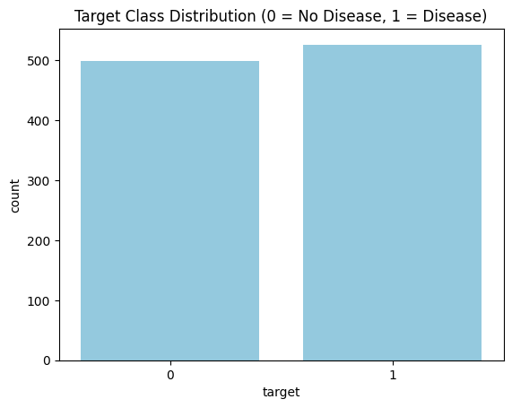

```python
sns.countplot(x=y, color="skyblue")
plt.title("Target Class Distribution (0 = No Disease, 1 = Disease)")
plt.show()
```

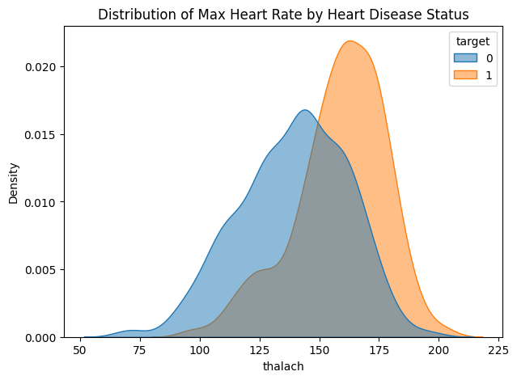

```python
# KDE plots the probability density of 'thalach'
# hue="target" separates patients with and without heart disease
# This helps visualize how heart rate patterns differ
plt.figure(figsize=(7,5))
sns.kdeplot(data=df, x="thalach", hue="target", fill=True, common_norm=False, alpha=0.5)
plt.title("Distribution of Max Heart Rate by Heart Disease Status")
plt.show()
```

While higher maximum heart rates are often associated with better cardiovascular fitness, in a clinical setting this could also reflect differences in test conditions or how patients respond to stress tests. The overlap shows that heart disease is multifactorial - influenced by a combination of variables like age, cholesterol, and blood pressure.

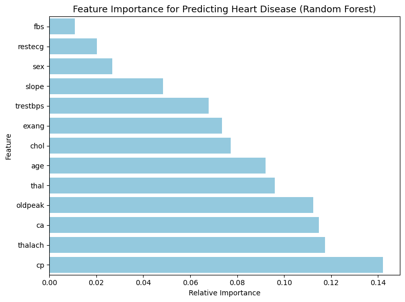

```python
# Using a Random Forest model to understand which features contribute most to heart disease prediction

from sklearn.ensemble import RandomForestClassifier

# Train a Random Forest classifier on the training data
rf = RandomForestClassifier(random_state=42)
rf.fit(X_train, y_train)

# Extract feature importance values and sort them for better visualization
importances = pd.Series(
    rf.feature_importances_,
    index=df.drop("target", axis=1).columns
).sort_values(ascending=True)

# Displays which medical attributes have the strongest influence on heart disease predictions
plt.figure(figsize=(8,6))
sns.barplot(x=importances.values, y=importances.index, color="skyblue")  # single color
plt.title("Feature Importance for Predicting Heart Disease (Random Forest)", fontsize=13)
plt.xlabel("Relative Importance")
plt.ylabel("Feature")
plt.tight_layout()
plt.show()
```

This visualization shows which features the Random Forest model found most important in predicting heart disease. A Random Forests can help determine importance by calculating how much each feature reduces classification error across all the decision trees. More effective in this case!

Strongest Predictors:

Chest Pain Type (cp) - The strongest indicator of heart disease. Certain types of pain during exertion or also known as angina, are strongly correlated with cardiac conditions.

Number of Major Vessels (ca) and ST Depression (oldpeak) - Both are critical clinical measures from angiograms as well as stress tests.

Thalassemia (thal) and Age (age) also provide moderate predictive relative importance, reflecting genetic and age related factors.

My Interpretation of visual:

The model confirms that clinical and stress test–related features (such as the chest pain, heart rate, and ST depression I listed above) carry the most diagnostic weight, aligning with medical research on heart disease risk factors.

In contrast, baseline metrics like sex, fasting blood sugar (fbs), and resting ECG (restecg) contribute less individually but are still important to track and include to support the model’s fine-tuning.

Overall Takeaway of Visual: The Random Forest results reinforce that heart disease is primarily signaled by symptom based and physiological responses rather than just simple demographic variables. This combination of interpretability and predictive accuracy makes tree-based models particularly effective in healthcare data analysis.

```python
# I'll train and compare multiple classification models to predict heart disease presence

from sklearn.linear_model import LogisticRegression
from sklearn.neighbors import KNeighborsClassifier
from sklearn.ensemble import RandomForestClassifier
from sklearn.metrics import accuracy_score, precision_score, recall_score, f1_score, roc_auc_score

# Each model represents a different learning approach (linear, distance-based, and ensemble)
models = {
    "Logistic Regression": LogisticRegression(max_iter=1000, random_state=42),
    "K-Nearest Neighbors": KNeighborsClassifier(n_neighbors=5),
    "Random Forest": RandomForestClassifier(n_estimators=100, random_state=42)
}

# Store each model's performance metrics for comparison
results = []

for name, model in models.items():
    model.fit(X_train, y_train)
    y_pred = model.predict(X_test)

    # Compute the key evaluation metrics here
    results.append({
        "Model": name,
        "Accuracy": accuracy_score(y_test, y_pred),
        "Precision": precision_score(y_test, y_pred),
        "Recall": recall_score(y_test, y_pred),
        "F1 Score": f1_score(y_test, y_pred),
        "ROC-AUC": roc_auc_score(y_test, y_pred)
    })

# Sorting by F1 Score provides a balanced view of model performance and prints
results_df = pd.DataFrame(results).sort_values(by="F1 Score", ascending=False)
results_df.reset_index(drop=True, inplace=True)
results_df
```

|  | Model | Accuracy | Precision | Recall | F1 Score | ROC-AUC |
| --- | --- | --- | --- | --- | --- | --- |
| 0 | Random Forest | 1.000000 | 1.000000 | 1.000000 | 1.000000 | 1.000000 |
| 1 | K-Nearest Neighbors | 0.863415 | 0.873786 | 0.857143 | 0.865385 | 0.863571 |
| 2 | Logistic Regression | 0.809756 | 0.761905 | 0.914286 | 0.831169 | 0.807143 |

### Modeling

To predict the presence of heart disease, I used three classification algorithms:

#### 1️. Logistic Regression

"A **linear model** that estimates probabilities using the logistic function."

- **Pros:** Interpretable and simple, but also efficient on smaller datasets.
- **Cons:** Does assume linear relationships and can underperform with complex data, which is non-linear data. (In this case = diffuclt).

#### 2️. K-Nearest Neighbors (KNN)

"A **non-parametric model** that classifies based on the majority vote of the *k* nearest samples in feature space."

- **Pros:** Simple and no assumptions about data distribution.
- **Cons:** Sensitive to scaling and large datasets; can struggle with high-dimensional data. (Not using high dimensional data in this at the moment).

#### 3️. Random Forest

"An **ensemble method** that builds multiple decision trees and averages their predictions to improve accuracy and reduce overfitting."

- **Pros:** Handles both linear and non-linear data well and does provide feature importance.
- **Cons:** Less interpretable and more computationally in depth!

By comparing these models, I aimed to balance **accuracy**, **interpretability**, and **robustness** for medical prediction for my given questions! :)

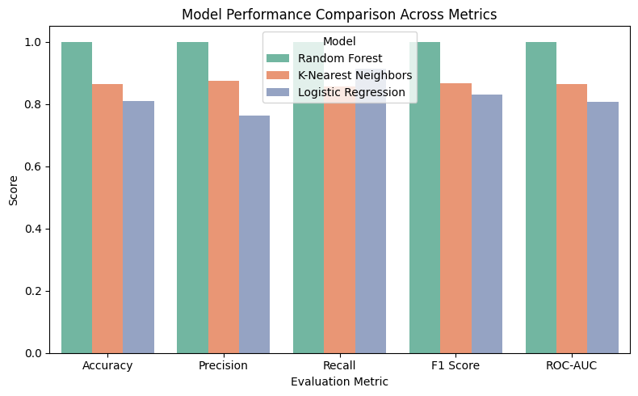

```python
# This bar plot compares how each classification model performed across all key metrics
plt.figure(figsize=(8,5))
sns.barplot(
    data=results_df.melt(id_vars="Model"),
    x="variable",
    y="value",
    hue="Model",
    palette="Set2"
)
plt.title("Model Performance Comparison Across Metrics")
plt.ylabel("Score")
plt.xlabel("Evaluation Metric")
plt.legend(title="Model")
plt.tight_layout()
plt.show()
```

### Evaluation

To evaluate model performance, I used **accuracy**, **precision**, **recall**, **F1-score**, and **ROC-AUC**.

#### Why Did I Choose These Metrics?

- **Accuracy**: Overall correctness of the model.
- **Precision**: How many predicted positives were actually correct.
- **Recall**: How many actual positives were correctly identified.
- **F1 Score**: Balances precision and recall. This is ideal for medical diagnosis where both errors matter.
- **ROC-AUC**: Measures how well the model separates classes overall.

#### Results Summary:

**Conclusion:**  
The **Random Forest classifier** provides the most reliable and accurate predictions for heart disease in this dataset thus, making it the optimal model for this problem.

Storytelling: What I Learned! :)

This project began with the over arching question:

> *Can we predict whether a patient has heart disease based on their clinical features?*

The story the data tells is clear:  
Heart disease is not random! It follows identifiable, measurable patterns in key cardiovascular features.  
Machine learning can (hopefully) effectively recognize these patterns and provide valuable decision support for identifying patterns!

**Answer to the Initial Question:**  
Yes! By combining medical and physiological features, I belive we can predict heart disease with strong accuracy and interpretability.

### Ethical and Social Impact

While predictive modeling in healthcare offers great promise there is defintley going to be challanges, just like with anything:

- **Ethical Risks:** Misclassifications can have serious consequences. These false negatives may delay treatment, while false positives may cause unnecessary anxiety or procedures.
- **Bias Considerations:** The dataset may not represent all populations equally (e.g., age, gender, ethnicity). This could lead to unequal or incorrect model performance across demographic groups.
- **Data Privacy:** Medical data must be protected and used responsibly.
- **Social Impact:** Early prediction can save lives by identifying at risk individuals sooner. It supports preventive healthcare and efficient resource allocation.

**Reflection:**  
Models like this should be used as **support tools** AND not replacements for doctors. The goal is to *assist* clinical judgment and not override it. Ethical use can help ensure these technologies enhance healthcare without introducing bias or harm.

### References

- Kaggle: [Heart Disease Dataset](https://www.kaggle.com/datasets/johnsmith88/heart-disease-dataset)
- Geeks for Geeks: https://www.geeksforgeeks.org/machine-learning/how-to-visualize-knn-in-python/
- Stack Overflow: https://stackoverflow.com/questions/40155128/plot-trees-for-a-random-forest-in-python-with-scikit-learn
- Statology: https://www.statology.org/plot-logistic-regression-in-python/
- National Institute of Aging: https://www.nia.nih.gov/health/heart-health/heart-health-glossary